# Assignment 4

In this assignment, you'll combine the assignment 3 data set with nutrition data from the [USDA Food Composition Databases](https://ndb.nal.usda.gov/ndb/search/list). The CSV file `fresh.csv` contains the fresh fruits and vegetables data you extracted in assignment 3.

The USDA Food Composition Databases have a [documented](https://ndb.nal.usda.gov/ndb/doc/index) web API that returns data in JSON format . You need a key in order to use the API. Only 1000 requests are allowed per hour, so it would be a good idea to use [caching](https://pypi.python.org/pypi/requests-cache).

[Sign up for an API key here](https://api.data.gov/signup/). The key will work with any Data.gov API. You may need the key again later in the quarter, so make sure you save it.

These modules may be useful:

- [requests](http://docs.python-requests.org/en/master/user/quickstart/)
- [requests_cache](https://pypi.python.org/pypi/requests-cache)
- [urlparse](https://docs.python.org/2/library/urlparse.html)
- [pandas](http://pandas.pydata.org/pandas-docs/stable/)

**Exercise 1.1.** Read the [search request documentation](https://ndb.nal.usda.gov/ndb/doc/apilist/API-SEARCH.md), then write a function called `ndb_search()` that makes a search request. The function should accept the search term as an argument. The function should return the search result items as a list (for 0 items, return an empty list).

Note that the search url is: `https://api.nal.usda.gov/ndb/search`

As an example, a search for `"quail eggs"` should return this list:

```
[{u'ds': u'BL',
  u'group': u'Branded Food Products Database',
  u'name': u'CHAOKOH, QUAIL EGG IN BRINE, UPC: 044738074186',
  u'ndbno': u'45094707',
  u'offset': 0},
 {u'ds': u'BL',
  u'group': u'Branded Food Products Database',
  u'name': u'L&W, QUAIL EGGS, UPC: 024072000256',
  u'ndbno': u'45094890',
  u'offset': 1},
 {u'ds': u'BL',
  u'group': u'Branded Food Products Database',
  u'name': u'BUDDHA, QUAIL EGGS IN BRINE, UPC: 761934535098',
  u'ndbno': u'45099560',
  u'offset': 2},
 {u'ds': u'BL',
  u'group': u'Branded Food Products Database',
  u'name': u'GRAN SABANA, QUAIL EGGS, UPC: 819140010103',
  u'ndbno': u'45169279',
  u'offset': 3},
 {u'ds': u'BL',
  u'group': u'Branded Food Products Database',
  u'name': u"D'ARTAGNAN, QUAIL EGGS, UPC: 736622102630",
  u'ndbno': u'45178254',
  u'offset': 4},
 {u'ds': u'SR',
  u'group': u'Dairy and Egg Products',
  u'name': u'Egg, quail, whole, fresh, raw',
  u'ndbno': u'01140',
  u'offset': 5}]
```

As usual, make sure you document and test your function.

```python
import requests
import pandas
import requests_cache
import random
from matplotlib import pyplot as plt
import numpy as np
def ndb_search(search,fresh = False,asdf = False):
    """This function takes in a search term (1 string) and passes it directly to the
    USDA Food Composition Database. It returns a list of items, or an empty list if the search
    term fails to return valid items."""
    api = "4y8emwdeDUa2nZkAdQRMN5sBhTu6g8Y1HtFL0fkM"
    url = "https://api.nal.usda.gov/ndb/search/?format=json&q=%s&sort=r&max=25&offset=0&api_key=%s"
    queryurl = url % (search,api)
    if fresh == True:
        ds = "&ds=Standard Reference"
        url = "https://api.nal.usda.gov/ndb/search/?format=json&q=%s%s&sort=r&max=25&offset=0&api_key=%s"
        queryurl = url % (search,ds,api)
    #This formats the url for the api
    requests_cache.install_cache('food_cache')
    r = requests.get(queryurl)
    #get request and creates a cache for requests to speed up repeat requests
    data = pandas.read_json(r.text)
    data = data.T
    #Creates a dataframe (makes it easier to format and extract data)
    if len(data.iloc[0]) == 1:
        return list()
        #Error checking for invalid search terms
    df = data['item']
    #gets list
    if asdf == True:
        df = pandas.DataFrame(df[0])
        return df
    return df[0]
```

```python
x = ndb_search("red bell pepper raw",True,True)
x.iloc[:1]
x.iloc[:1:2]
```

|  | ds | group | name | ndbno | offset |
| --- | --- | --- | --- | --- | --- |
| 0 | SR | Vegetables and Vegetable Products | Peppers, sweet, red, raw | 11821 | 0 |

**Exercise 1.2.** Use your search function to get NDB numbers for the foods in the `fresh.csv` file. It's okay if you don't get an NDB number for every food, but try to come up with a strategy that gets most of them. Discuss your strategy in a short paragraph.

Hints:

- The foods are all raw and unbranded.
- You can test search terms with the [online search page](https://ndb.nal.usda.gov/ndb/search/list).
- You can convert the output of `ndb_search()` to a data frame with `pd.DataFrame()`.
- The string methods for [Python](https://docs.python.org/2/library/stdtypes.html#string-methods) and [Pandas](http://pandas.pydata.org/pandas-docs/stable/text.html#method-summary) are useful here. It's okay if you use *simple* regular expressions in the Pandas methods, although this exercise can be solved without them.
- You can merge data frames that have a column in common with `pd.merge()`.

```python
def findfoods(food):
    """Takes String Gives DataFrame"""
    append = " raw"
    search = food + append
    item = ndb_search(search,True,True)
    if len(item)==0:
        x = pandas.DataFrame( "none",index = [random.randint(100,10000000)], columns= ["ds","group","name","ndbno","offset"])
        return x
    else:
        return item.iloc[:1]
```

```python
findfoods("sweet potato raw")
```

|  | ds | group | name | ndbno | offset |
| --- | --- | --- | --- | --- | --- |
| 0 | SR | Vegetables and Vegetable Products | Sweet potato leaves, raw | 11505 | 0 |

```python
fresh = pandas.read_csv('fresh.csv')
fresh
```

|  | form | price_per_lb | yield | lb_per_cup | price_per_cup | food | type |
| --- | --- | --- | --- | --- | --- | --- | --- |
| 0 | Fresh1 | 0.333412 | 0.520000 | 0.330693 | 0.212033 | watermelon | fruit |
| 1 | Fresh1 | 0.535874 | 0.510000 | 0.374786 | 0.393800 | cantaloupe | fruit |
| 2 | Fresh1 | 1.377962 | 0.740000 | 0.407855 | 0.759471 | tangerines | fruit |
| 3 | Fresh1 | 2.358808 | 0.940000 | 0.319670 | 0.802171 | strawberries | fruit |
| 4 | Fresh1 | 1.827416 | 0.940000 | 0.363763 | 0.707176 | plums | fruit |
| 5 | Fresh1 | 1.035173 | 0.730000 | 0.407855 | 0.578357 | oranges | fruit |
| 6 | Fresh1 | 6.975811 | 0.960000 | 0.319670 | 2.322874 | raspberries | fruit |
| 7 | Fresh1 | 2.173590 | 0.560000 | 0.341717 | 1.326342 | pomegranate | fruit |
| 8 | Fresh1 | 0.627662 | 0.510000 | 0.363763 | 0.447686 | pineapple | fruit |
| 9 | Fresh1 | 3.040072 | 0.930000 | 0.363763 | 1.189102 | apricots | fruit |
| 10 | Fresh1 | 0.796656 | 0.460000 | 0.374786 | 0.649077 | honeydew | fruit |
| 11 | Fresh1 | 1.298012 | 0.620000 | 0.308647 | 0.646174 | papaya | fruit |
| 12 | Fresh1 | 2.044683 | 0.760000 | 0.385809 | 1.037970 | kiwi | fruit |
| 13 | Fresh1 | 3.592990 | 0.920000 | 0.341717 | 1.334548 | cherries | fruit |
| 14 | Fresh1 | 0.566983 | 0.640000 | 0.330693 | 0.292965 | bananas | fruit |
| 15 | Fresh1 | 1.567515 | 0.900000 | 0.242508 | 0.422373 | apples | fruit |
| 16 | Fresh1 | 1.591187 | 0.960000 | 0.341717 | 0.566390 | peaches | fruit |
| 17 | Fresh1 | 1.761148 | 0.910000 | 0.319670 | 0.618667 | nectarines | fruit |
| 18 | Fresh1 | 1.461575 | 0.900000 | 0.363763 | 0.590740 | pears | fruit |
| 19 | Fresh1 | 0.897802 | 0.490000 | 0.462971 | 0.848278 | grapefruit | fruit |
| 20 | Fresh1 | 5.774708 | 0.960000 | 0.319670 | 1.922919 | blackberries | fruit |
| 21 | Fresh1 | 2.093827 | 0.960000 | 0.330693 | 0.721266 | grapes | fruit |
| 22 | Fresh1 | 4.734622 | 0.950000 | 0.319670 | 1.593177 | blueberries | fruit |
| 23 | Fresh1 | 1.377563 | 0.710000 | 0.363763 | 0.705783 | mangoes | fruit |
| 24 | Fresh1 | 3.213494 | 0.493835 | 0.396832 | 2.582272 | asparagus | vegetables |
| 25 | Fresh, consumed with peel1 | 1.295931 | 0.970000 | 0.264555 | 0.353448 | cucumbers | vegetables |
| 26 | Fresh, peeled1 | 1.295931 | 0.730000 | 0.264555 | 0.469650 | cucumbers | vegetables |
| 27 | Fresh1 | 1.213039 | 0.950000 | 0.242508 | 0.309655 | lettuce_iceberg | vegetables |
| 28 | Fresh1 | 1.038107 | 0.900000 | 0.352740 | 0.406868 | onions | vegetables |
| 29 | Fresh1 | 2.471749 | 0.750000 | 0.319670 | 1.053526 | turnip_greens | vegetables |
| 30 | Fresh1 | 2.569235 | 0.840000 | 0.308647 | 0.944032 | mustard_greens | vegetables |
| 31 | Fresh1 | 0.564320 | 0.811301 | 0.264555 | 0.184017 | potatoes | vegetables |
| 32 | Fresh1 | 2.630838 | 1.160000 | 0.286601 | 0.650001 | collard_greens | vegetables |
| 33 | Fresh1 | 2.139972 | 0.846575 | 0.275578 | 0.696606 | green_beans | vegetables |
| 34 | Fresh1 | 1.172248 | 0.458554 | 0.451948 | 1.155360 | acorn_squash | vegetables |
| 35 | Fresh1 | 2.277940 | 0.820000 | 0.264555 | 0.734926 | red_peppers | vegetables |
| 36 | Fresh green cabbage1 | 0.579208 | 0.778797 | 0.330693 | 0.245944 | cabbage | vegetables |
| 37 | Fresh red cabbage1 | 1.056450 | 0.779107 | 0.330693 | 0.448412 | cabbage | vegetables |
| 38 | Fresh1 | 0.918897 | 0.811301 | 0.440925 | 0.499400 | sweet_potatoes | vegetables |
| 39 | Fresh1 | 1.639477 | 0.769500 | 0.396832 | 0.845480 | summer_squash | vegetables |
| 40 | Fresh1 | 1.311629 | 0.900000 | 0.275578 | 0.401618 | radish | vegetables |
| 41 | Fresh1 | 1.244737 | 0.714000 | 0.451948 | 0.787893 | butternut_squash | vegetables |
| 42 | Fresh1 | 2.235874 | 0.740753 | 0.319670 | 0.964886 | avocados | vegetables |
| 43 | Fresh1 | 2.807302 | 1.050000 | 0.286601 | 0.766262 | kale | vegetables |
| 44 | Fresh1 | 2.213050 | 0.375309 | 0.385809 | 2.274967 | artichoke | vegetables |
| 45 | Fresh1 | 3.213552 | 0.769474 | 0.352740 | 1.473146 | okra | vegetables |
| 46 | Fresh1 | 1.410363 | 0.820000 | 0.264555 | 0.455022 | green_peppers | vegetables |
| 47 | Fresh1 | 2.763553 | 1.060000 | 0.341717 | 0.890898 | brussels_sprouts | vegetables |
| 48 | Fresh1 | 2.690623 | 0.540000 | 0.363763 | 1.812497 | corn_sweet | vegetables |

```python
def createfooddf(df):
    dfprime = pandas.DataFrame()
    for i in df['food']:
        food = i.replace("_"," ")
        temp = findfoods(food)
        foodindex = pandas.DataFrame([i],columns=['food'])
        temp['food'] = i
        dfprime = dfprime.append(temp,ignore_index = True)
    return dfprime
```

```python
x = createfooddf(fresh)
x
```

|  | ds | group | name | ndbno | offset | food |
| --- | --- | --- | --- | --- | --- | --- |
| 0 | SR | Fruits and Fruit Juices | Watermelon, raw | 09326 | 0 | watermelon |
| 1 | SR | Fruits and Fruit Juices | Melons, cantaloupe, raw | 09181 | 0 | cantaloupe |
| 2 | SR | Fruits and Fruit Juices | Tangerine juice, raw | 09221 | 0 | tangerines |
| 3 | SR | Fruits and Fruit Juices | Strawberries, raw | 09316 | 0 | strawberries |
| 4 | SR | Fruits and Fruit Juices | Plums, raw | 09279 | 0 | plums |
| 5 | SR | Fruits and Fruit Juices | Oranges, raw, California, valencias | 09201 | 0 | oranges |
| 6 | SR | Fruits and Fruit Juices | Raspberries, raw | 09302 | 0 | raspberries |
| 7 | SR | Fruits and Fruit Juices | Pomegranates, raw | 09286 | 0 | pomegranate |
| 8 | SR | Fruits and Fruit Juices | Pineapple, raw, all varieties | 09266 | 0 | pineapple |
| 9 | SR | Fruits and Fruit Juices | Apricots, raw | 09021 | 0 | apricots |
| 10 | SR | Fruits and Fruit Juices | Melons, honeydew, raw | 09184 | 0 | honeydew |
| 11 | SR | Fruits and Fruit Juices | Papayas, raw | 09226 | 0 | papaya |
| 12 | none | none | none | none | none | kiwi |
| 13 | SR | Fruits and Fruit Juices | Pitanga, (surinam-cherry), raw | 09276 | 0 | cherries |
| 14 | SR | Fruits and Fruit Juices | Bananas, raw | 09040 | 0 | bananas |
| 15 | SR | Fruits and Fruit Juices | Apples, raw, with skin | 09003 | 0 | apples |
| 16 | SR | Fruits and Fruit Juices | Peaches, yellow, raw | 09236 | 0 | peaches |
| 17 | SR | Fruits and Fruit Juices | Nectarines, raw | 09191 | 0 | nectarines |
| 18 | SR | Fruits and Fruit Juices | Pears, raw | 09252 | 0 | pears |
| 19 | SR | Fruits and Fruit Juices | Grapefruit, raw, white, California | 09117 | 0 | grapefruit |
| 20 | SR | Fruits and Fruit Juices | Blackberries, raw | 09042 | 0 | blackberries |
| 21 | SR | Fruits and Fruit Juices | Grapes, muscadine, raw | 09129 | 0 | grapes |
| 22 | SR | Fruits and Fruit Juices | Blueberries, raw | 09050 | 0 | blueberries |
| 23 | SR | Fruits and Fruit Juices | Mangos, raw | 09176 | 0 | mangoes |
| 24 | SR | Vegetables and Vegetable Products | Asparagus, raw | 11011 | 0 | asparagus |
| 25 | SR | Vegetables and Vegetable Products | Cucumber, peeled, raw | 11206 | 0 | cucumbers |
| 26 | SR | Vegetables and Vegetable Products | Cucumber, peeled, raw | 11206 | 0 | cucumbers |
| 27 | SR | Vegetables and Vegetable Products | Lettuce, iceberg (includes crisphead types), raw | 11252 | 0 | lettuce_iceberg |
| 28 | SR | Vegetables and Vegetable Products | Onions, raw | 11282 | 0 | onions |
| 29 | SR | Vegetables and Vegetable Products | Turnip greens, raw | 11568 | 0 | turnip_greens |
| 30 | SR | Vegetables and Vegetable Products | Mustard greens, raw | 11270 | 0 | mustard_greens |
| 31 | SR | Vegetables and Vegetable Products | Potatoes, raw, skin | 11362 | 0 | potatoes |
| 32 | SR | Vegetables and Vegetable Products | Collards, raw | 11161 | 0 | collard_greens |
| 33 | SR | Vegetables and Vegetable Products | Beans, snap, green, raw | 11052 | 0 | green_beans |
| 34 | SR | Vegetables and Vegetable Products | Squash, winter, acorn, raw | 11482 | 0 | acorn_squash |
| 35 | SR | Vegetables and Vegetable Products | Peppers, sweet, red, raw | 11821 | 0 | red_peppers |
| 36 | SR | Vegetables and Vegetable Products | Swamp cabbage, (skunk cabbage), raw | 11503 | 0 | cabbage |
| 37 | SR | Vegetables and Vegetable Products | Swamp cabbage, (skunk cabbage), raw | 11503 | 0 | cabbage |
| 38 | SR | Vegetables and Vegetable Products | Sweet potato, raw, unprepared | 11507 | 0 | sweet_potatoes |
| 39 | SR | Vegetables and Vegetable Products | Squash, summer, scallop, raw | 11475 | 0 | summer_squash |
| 40 | SR | Vegetables and Vegetable Products | Radishes, raw | 11429 | 0 | radish |
| 41 | SR | Vegetables and Vegetable Products | Squash, winter, butternut, raw | 11485 | 0 | butternut_squash |
| 42 | SR | Fruits and Fruit Juices | Avocados, raw, California | 09038 | 0 | avocados |
| 43 | SR | Vegetables and Vegetable Products | Kale, raw | 11233 | 0 | kale |
| 44 | SR | Vegetables and Vegetable Products | Jerusalem-artichokes, raw | 11226 | 0 | artichoke |
| 45 | SR | Vegetables and Vegetable Products | Okra, raw | 11278 | 0 | okra |
| 46 | SR | Vegetables and Vegetable Products | Peppers, sweet, green, raw | 11333 | 0 | green_peppers |
| 47 | SR | Vegetables and Vegetable Products | Brussels sprouts, raw | 11098 | 0 | brussels_sprouts |
| 48 | SR | Vegetables and Vegetable Products | Corn, sweet, white, raw | 11900 | 0 | corn_sweet |

**Exercise 1.3.** Read the [food reports V2 documentation](https://ndb.nal.usda.gov/ndb/doc/apilist/API-FOOD-REPORTV2.md), then write a function called `ndb_report()` that requests a *basic* food report. The function should accept the NDB number as an argument and return the list of nutrients for the food.

Note that the report url is: `https://api.nal.usda.gov/ndb/V2/reports`

For example, for `"09279"` (raw plums) the first element of the returned list should be:

```
{u'group': u'Proximates',
 u'measures': [{u'eqv': 165.0,
   u'eunit': u'g',
   u'label': u'cup, sliced',
   u'qty': 1.0,
   u'value': u'143.93'},
  {u'eqv': 66.0,
   u'eunit': u'g',
   u'label': u'fruit (2-1/8" dia)',
   u'qty': 1.0,
   u'value': u'57.57'},
  {u'eqv': 151.0,
   u'eunit': u'g',
   u'label': u'NLEA serving',
   u'qty': 1.0,
   u'value': u'131.72'}],
 u'name': u'Water',
 u'nutrient_id': u'255',
 u'unit': u'g',
 u'value': u'87.23'}
```

Be sure to document and test your function.

```python
def ndb_report(search,asdf = False):
    """This function takes in a search term (1 string) and passes it directly to the
    USDA Food Composition Database. """
    api = "4y8emwdeDUa2nZkAdQRMN5sBhTu6g8Y1HtFL0fkM"
    url = "https://api.nal.usda.gov/ndb/V2/reports?ndbno=%s&type=b&format=json&api_key=%s"
    queryurl = url % (search,api)
    #This formats the url for the api
    requests_cache.install_cache('food_cache2')
    r = requests.get(queryurl)
    #get request and creates a cache for requests to speed up repeat requests
    data = pandas.read_json(r.text)
    #Creates a dataframe (makes it easier to format and extract data)
    df = data['foods'][0]
    #gets list
    df = pandas.DataFrame(df).T
    if asdf == True:
        return pandas.DataFrame(df['nutrients'][0])
    return df['nutrients'][0]
```

```python
ndb_report(11900,True)
```

|  | group | measures | name | nutrient_id | unit | value |
| --- | --- | --- | --- | --- | --- | --- |
| 0 | Proximates | [{u'eunit': u'g', u'eqv': 73.0, u'qty': 1.0, u... | Water | 255 | g | 75.96 |
| 1 | Proximates | [{u'eunit': u'g', u'eqv': 73.0, u'qty': 1.0, u... | Energy | 208 | kcal | 86 |
| 2 | Proximates | [{u'eunit': u'g', u'eqv': 73.0, u'qty': 1.0, u... | Protein | 203 | g | 3.22 |
| 3 | Proximates | [{u'eunit': u'g', u'eqv': 73.0, u'qty': 1.0, u... | Total lipid (fat) | 204 | g | 1.18 |
| 4 | Proximates | [{u'eunit': u'g', u'eqv': 73.0, u'qty': 1.0, u... | Carbohydrate, by difference | 205 | g | 19.02 |
| 5 | Proximates | [{u'eunit': u'g', u'eqv': 73.0, u'qty': 1.0, u... | Fiber, total dietary | 291 | g | 2.7 |
| 6 | Proximates | [{u'eunit': u'g', u'eqv': 73.0, u'qty': 1.0, u... | Sugars, total | 269 | g | 3.22 |
| 7 | Minerals | [{u'eunit': u'g', u'eqv': 73.0, u'qty': 1.0, u... | Calcium, Ca | 301 | mg | 2 |
| 8 | Minerals | [{u'eunit': u'g', u'eqv': 73.0, u'qty': 1.0, u... | Iron, Fe | 303 | mg | 0.52 |
| 9 | Minerals | [{u'eunit': u'g', u'eqv': 73.0, u'qty': 1.0, u... | Magnesium, Mg | 304 | mg | 37 |
| 10 | Minerals | [{u'eunit': u'g', u'eqv': 73.0, u'qty': 1.0, u... | Phosphorus, P | 305 | mg | 89 |
| 11 | Minerals | [{u'eunit': u'g', u'eqv': 73.0, u'qty': 1.0, u... | Potassium, K | 306 | mg | 270 |
| 12 | Minerals | [{u'eunit': u'g', u'eqv': 73.0, u'qty': 1.0, u... | Sodium, Na | 307 | mg | 15 |
| 13 | Minerals | [{u'eunit': u'g', u'eqv': 73.0, u'qty': 1.0, u... | Zinc, Zn | 309 | mg | 0.45 |
| 14 | Vitamins | [{u'eunit': u'g', u'eqv': 73.0, u'qty': 1.0, u... | Vitamin C, total ascorbic acid | 401 | mg | 6.8 |
| 15 | Vitamins | [{u'eunit': u'g', u'eqv': 73.0, u'qty': 1.0, u... | Thiamin | 404 | mg | 0.200 |
| 16 | Vitamins | [{u'eunit': u'g', u'eqv': 73.0, u'qty': 1.0, u... | Riboflavin | 405 | mg | 0.060 |
| 17 | Vitamins | [{u'eunit': u'g', u'eqv': 73.0, u'qty': 1.0, u... | Niacin | 406 | mg | 1.700 |
| 18 | Vitamins | [{u'eunit': u'g', u'eqv': 73.0, u'qty': 1.0, u... | Vitamin B-6 | 415 | mg | 0.055 |
| 19 | Vitamins | [{u'eunit': u'g', u'eqv': 73.0, u'qty': 1.0, u... | Folate, DFE | 435 | µg | 46 |
| 20 | Vitamins | [{u'eunit': u'g', u'eqv': 73.0, u'qty': 1.0, u... | Vitamin B-12 | 418 | µg | 0.00 |
| 21 | Vitamins | [{u'eunit': u'g', u'eqv': 73.0, u'qty': 1.0, u... | Vitamin A, RAE | 320 | µg | 0 |
| 22 | Vitamins | [{u'eunit': u'g', u'eqv': 73.0, u'qty': 1.0, u... | Vitamin A, IU | 318 | IU | 1 |
| 23 | Vitamins | [{u'eunit': u'g', u'eqv': 73.0, u'qty': 1.0, u... | Vitamin E (alpha-tocopherol) | 323 | mg | 0.07 |
| 24 | Vitamins | [{u'eunit': u'g', u'eqv': 73.0, u'qty': 1.0, u... | Vitamin D (D2 + D3) | 328 | µg | 0.0 |
| 25 | Vitamins | [{u'eunit': u'g', u'eqv': 73.0, u'qty': 1.0, u... | Vitamin D | 324 | IU | 0 |
| 26 | Vitamins | [{u'eunit': u'g', u'eqv': 73.0, u'qty': 1.0, u... | Vitamin K (phylloquinone) | 430 | µg | 0.3 |
| 27 | Lipids | [{u'eunit': u'g', u'eqv': 73.0, u'qty': 1.0, u... | Fatty acids, total saturated | 606 | g | 0.182 |
| 28 | Lipids | [{u'eunit': u'g', u'eqv': 73.0, u'qty': 1.0, u... | Fatty acids, total monounsaturated | 645 | g | 0.347 |
| 29 | Lipids | [{u'eunit': u'g', u'eqv': 73.0, u'qty': 1.0, u... | Fatty acids, total polyunsaturated | 646 | g | 0.559 |
| 30 | Lipids | [{u'eunit': u'g', u'eqv': 73.0, u'qty': 1.0, u... | Fatty acids, total trans | 605 | g | 0.000 |
| 31 | Lipids | [{u'eunit': u'g', u'eqv': 73.0, u'qty': 1.0, u... | Cholesterol | 601 | mg | 0 |
| 32 | Other | [{u'eunit': u'g', u'eqv': 73.0, u'qty': 1.0, u... | Caffeine | 262 | mg | 0 |

```python
def filterdf(df,by):
    df1 = df[df.name.str.contains(by)]
    df1.drop(df.columns[[0, 1, 3,4]], axis=1,inplace = True)
    return df1
```

```python
def createnutrientdf(df,by):
    dfprime = pandas.DataFrame()
    for i in df['ndbno']:
        if i == 'none':
            continue
        temp = ndb_report(i,True)
        temp1 = filterdf(temp,by)
        temp1['ndbno'] = i
        dfprime = dfprime.append(temp1,ignore_index = True)
    return dfprime
```

```python
y = createnutrientdf(x,'Energy')
p = createnutrientdf(x,'Protein')
c = createnutrientdf(x,'Carbohydrate')
f = createnutrientdf(x,'Total lipid')
```

[output not shown]

```python
dfs = [y,p,c,f]
x1 = x.merge(y,on = 'ndbno')
x2 = x1.merge(p,on='ndbno')
x3 = x2.merge(c,on='ndbno')
x4 = x3.merge(f,on='ndbno')
fresher = fresh.merge(x4, on = 'food')
```

**Exercise 1.4.** Which foods provide the best combination of price, yield, and nutrition? You can use kilocalories as a measure of "nutrition" here, but more a detailed analysis is better. Use plots to support your analysis.

```python
fresher['price/yield'] = fresher['price_per_lb']/fresher['yield']
```

```python
fresher['bestcal'] = fresher.ix[:,13].astype('float')/fresher['price/yield']
fresher['bestpro'] = fresher.ix[:,15].astype('float')/fresher['price/yield']
fresher['bestcarb'] = fresher.ix[:,17].astype('float')/fresher['price/yield']
fresher['bestfat'] = fresher.ix[:,19].astype('float')/fresher['price/yield']
```

```python
final = fresher.ix[:,[5,21,22,23,24]]
final.drop_duplicates(inplace = True)
final.reset_index()
```

[output not shown]

|  | index | food | bestcal | bestpro | bestcarb | bestfat |
| --- | --- | --- | --- | --- | --- | --- |
| 0 | 0 | watermelon | 46.788953 | 0.951375 | 11.775220 | 0.233945 |
| 1 | 1 | cantaloupe | 32.358366 | 0.799442 | 7.766008 | 0.180826 |
| 2 | 2 | tangerines | 23.092076 | 0.268513 | 5.423953 | 0.107405 |
| 3 | 3 | strawberries | 12.752201 | 0.266999 | 3.060528 | 0.119552 |
| 4 | 4 | plums | 23.661826 | 0.360071 | 5.874306 | 0.144029 |
| 5 | 5 | oranges | 34.554620 | 0.733404 | 8.384784 | 0.211559 |
| 6 | 6 | raspberries | 7.156157 | 0.165142 | 1.643164 | 0.089452 |
| 7 | 7 | pomegranate | 21.383974 | 0.430256 | 4.817835 | 0.301437 |
| 8 | 8 | pineapple | 40.626965 | 0.438771 | 10.660516 | 0.097505 |
| 9 | 9 | apricots | 14.683863 | 0.428279 | 3.401762 | 0.119306 |
| 10 | 10 | honeydew | 20.786884 | 0.311803 | 5.248688 | 0.080838 |
| 11 | 11 | papaya | 20.539108 | 0.224497 | 5.168213 | 0.124190 |
| 12 | 12 | cherries | 8.449788 | 0.204843 | 1.917846 | 0.102422 |
| 13 | 13 | bananas | 100.461492 | 1.230371 | 25.781354 | 0.372498 |
| 14 | 14 | apples | 29.856166 | 0.149281 | 7.929109 | 0.097607 |
| 15 | 15 | peaches | 23.529606 | 0.549024 | 5.755704 | 0.150831 |
| 16 | 16 | nectarines | 22.735164 | 0.547711 | 5.451272 | 0.165347 |
| 17 | 17 | pears | 35.099132 | 0.221679 | 9.378242 | 0.086208 |
| 18 | 18 | grapefruit | 20.193761 | 0.480284 | 4.961116 | 0.054578 |
| 19 | 19 | blackberries | 7.148413 | 0.231077 | 1.597587 | 0.081459 |
| 20 | 20 | grapes | 26.133959 | 0.371377 | 6.386773 | 0.215491 |
| 21 | 21 | blueberries | 11.437028 | 0.148481 | 2.907413 | 0.066214 |
| 22 | 22 | mangoes | 30.924165 | 0.422630 | 7.720733 | 0.195853 |
| 23 | 23 | asparagus | 3.073511 | 0.338086 | 0.596261 | 0.018441 |
| 24 | 24 | cucumbers | 8.981957 | 0.441613 | 1.616752 | 0.119759 |
| 25 | 56 | cucumbers | 6.759617 | 0.332348 | 1.216731 | 0.090128 |
| 26 | 88 | lettuce_iceberg | 10.964194 | 0.704841 | 2.325976 | 0.109642 |
| 27 | 89 | onions | 34.678501 | 0.953659 | 8.097430 | 0.086696 |
| 28 | 90 | turnip_greens | 9.709724 | 0.455143 | 2.163448 | 0.091029 |
| 29 | 91 | mustard_greens | 8.827530 | 0.935064 | 1.526836 | 0.137317 |
| 30 | 92 | potatoes | 83.384393 | 3.694791 | 17.884515 | 0.143766 |
| 31 | 93 | collard_greens | 14.109573 | 1.331591 | 2.389809 | 0.268964 |
| 32 | 94 | green_beans | 12.263630 | 0.723950 | 2.757339 | 0.087032 |
| 33 | 95 | acorn_squash | 15.646991 | 0.312940 | 4.076041 | 0.039117 |
| 34 | 96 | red_peppers | 11.159207 | 0.356375 | 2.170646 | 0.107992 |
| 35 | 97 | cabbage | 25.547186 | 3.495931 | 4.222009 | 0.268918 |
| 36 | 129 | cabbage | 14.012050 | 1.917438 | 2.315676 | 0.147495 |
| 37 | 161 | sweet_potatoes | 75.930089 | 1.386166 | 17.764109 | 0.044145 |
| 38 | 162 | summer_squash | 8.448426 | 0.563228 | 1.802331 | 0.093871 |
| 39 | 163 | radish | 10.978716 | 0.466595 | 2.332977 | 0.068617 |
| 40 | 164 | butternut_squash | 25.812688 | 0.573615 | 6.705563 | 0.057362 |
| 41 | 165 | avocados | 55.327699 | 0.649355 | 2.862463 | 5.105388 |
| 42 | 166 | kale | 18.327207 | 1.600825 | 3.272715 | 0.347843 |
| 43 | 167 | artichoke | 12.379985 | 0.339178 | 2.957629 | 0.001696 |
| 44 | 168 | okra | 7.901733 | 0.462132 | 1.783876 | 0.045495 |
| 45 | 169 | green_peppers | 11.628215 | 0.500013 | 2.697746 | 0.098840 |
| 46 | 170 | brussels_sprouts | 16.493258 | 1.296447 | 3.432899 | 0.115069 |
| 47 | 171 | corn_sweet | 17.259942 | 0.646244 | 3.817257 | 0.236822 |

```python
def generatescatters(df):
    mylist = range(1,5)
    for i in mylist:
        N = len(df['food'])
        plt.figure(figsize=(15, 6))
        plt.bar(left = np.arange(N),height = df.ix[:,i])
        plt.xticks(np.arange(N),df['food'], rotation='vertical')
        plt.xlabel("Food")
        plt.ylabel(df.columns[i])
        plt.show()
    return
```

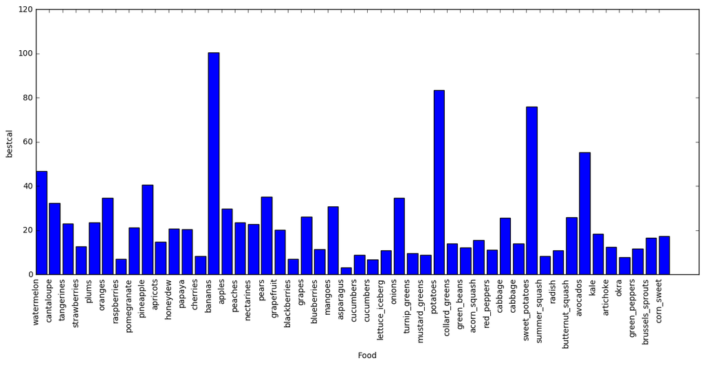

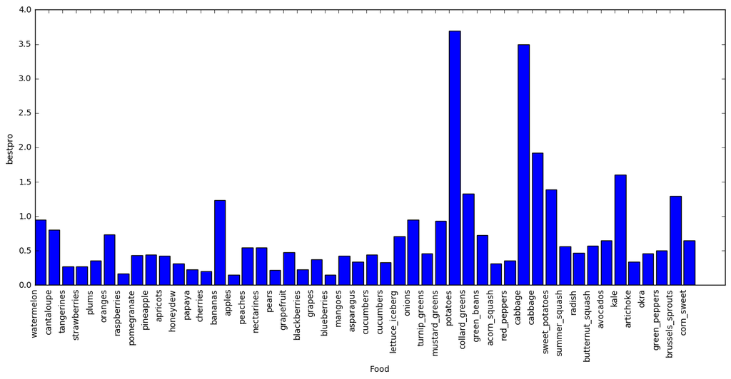

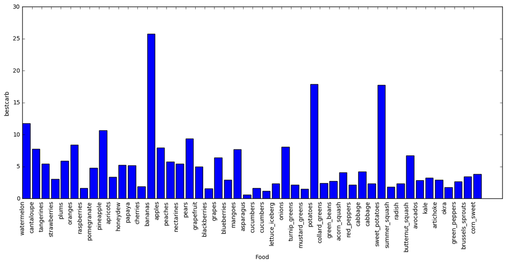

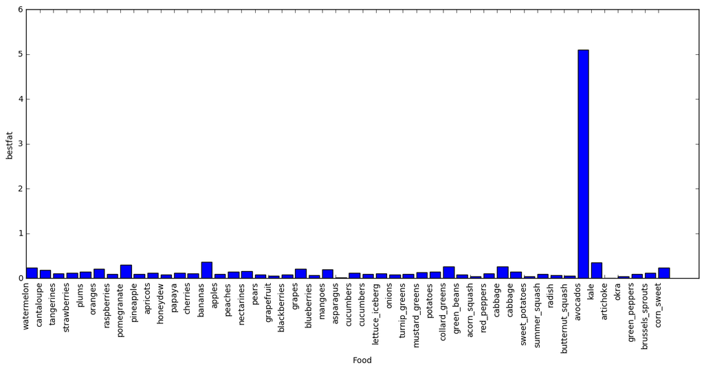

```python
generatescatters(final)
```

Looking at the best nutrition per dollar (Price per pound / %yield)*(Value of nutrient per 100g) These numbers are not exact, rather they are relative to the other foods in the table. We chose the Calories, Protien, Carbohydrates, and Total Fat as our measured nutrients, because these are the most important macronutrients we have data for. The following are the results of our analysis. Best Calories by Price Accounting for Yield:Bananas Best Protein by Price Accounting for Yield: Potatoes Best Carbohydrates by Price Accounting for Yield: Bananas Best Fat by Price Accounting for Yield: Avacadoes